# Reproducible Analysis and Documentation

Fall 2022

## Slides Usage Notes

- Recommended to press `w` for widescreen view.
- Also recommended to press `f` for fullscreen view.
- Press `p` for Presenter Notes.
- These slides are licensed as CC-BY.

## Before we begin

- Open RStudio. Make sure updated to v 1.4 if using Visual Editor
- Be sure you can find the `penguins` demo project you downloaded

## Learning Objectives

In this workshop, you will learn:

- How to use *RStudio Projects* and why you would want to
- What *R Markdown* documents are and why you would want to use them

Note: This is not a complete workshop on how to use the many options provided within R Markdown documents. We will cover some details, but not all.

## Why a project-oriented workflow?

Working with projects allows you to:

- Work on more than one project at a time
- Easily distribute and collaborate on projects
- Easily stop and pick up where you left off

## How to do a project-oriented workflow?

Use:

- A dedicated directory
- RStudio Projects
- Git repo

## Project-oriented workflow with RStudio Projects

*What not to do:* `setwd()` and `rm(list = ls())`

A lot of R scripts start off like this:

`setwd("C:/Users/jah2ax.ESERVICES/Box Sync/_R/research/penguins")`

You might also see:

`rm(list = ls())`

Fortunately, a project-oriented workflow designs this away.

## What persists after rm(list=ls())?

| Option | Persists? (Y/N) |
| --- | --- |
| library(dplyr) |  |
| summary <- head |  |
| options(stringsAsFactors = FALSE) |  |
| Sys.setenv(LANGUAGE = “fr”) |  |
| x <- 1:5 |  |
| attach(iris) |  |

*Examples taken from Pileggi 2022*

## What persists after rm(list=ls())?

| Option | Persists? |
| --- | --- |
| library(dplyr) | Yes |
| summary <- head | No |
| options(stringsAsFactors = FALSE) | Yes |
| Sys.setenv(LANGUAGE = “fr”) | Yes |
| x <- 1:5 | No |
| attach(iris) | Yes |

*Examples taken from Pileggi 2022*

## Organize work into projects

AKA “little p projects”

1. Use a single directory for your research project
2. Set working directory in R to that main directory
3. Use relative paths

## Organize work into projects

Example of a simple file structure for a project

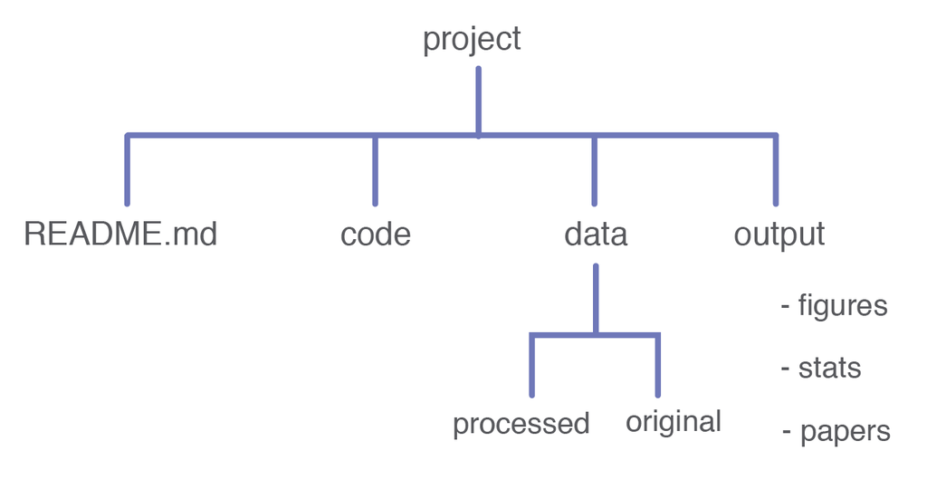

*from https://reproducible-science-curriculum.github.io/organization-RR-Jupyter/slides/02_slideshow_organization.slides.html#/1*

## What RStudio Projects can do for you

AKA “Capital P Projects”

When you launch an RStudio Project, RStudio will:

1. Launch R/RStudio.
2. Set the working directory to the project’s folder.
3. Provide you with a fresh environment. That means there are no libraries loaded and no objects saved in your environment.

## Your Turn: RStudio Projects

As an example, we will imagine you are working on two projects: `polar-bears` and `penguins`.

You can designate a new or existing folder as an RStudio Project. All that means is that RStudio leaves behind a helper file, e.g., `polar-bears.Rproj`. This file stores specific settings for that project.

–

In RStudio, use *File…New Project…New Directory* or click on the R cube in the upper right to get started. Create a fresh project called `polar-bears`.

Now click on the little down arrow next to the R cube in the upper right, click *Open Project*, and open the `penguins` project you downloaded.

Notice that you get a fresh environment when you switch back and forth.

Using Windows Explorer or Mac Finder, go to where you saved the `polar-bears` project. Double click on the `polar-bears.rproj` file. RStudio will launch your project, and you can run multiple instances of R at the same time. You should have both `polar-bears` and `penguins` projects open at the same time, using two RStudio instances. They are running in completely separate environments.

## Dynamic Documents with R Markdown: No more cut and paste!

With R Markdown, you can:

- Compile a single R Markdown document to a report in different formats, such as PDF, HTML, or Word.
- Create notebooks in which you can directly run code chunks interactively.
- Make slides for presentations (like this one!).
- Produce dashboards with flexible, interactive, and attractive layouts.
- Build interactive applications based on Shiny.
- Write journal articles.
- Author books of multiple chapters.
- Generate websites and blogs.

## R Markdown Visual Editor

R Markdown Visual Editor brings some of the features and ease-of-use that GUIs provide, while still always maintaining the source code that is the .Rmd file (R Markdown file).

## Bonus: `here` package

Paths created relative to the top level directory.

The `here` package enables easy file referencing with project-oriented workflows. Paths are created relative to the top-level directory. It is most useful when you work with R Markdown documents a lot, as it smoothes out some of the idiosyncrasies of how R Markdown looks for files.

The here package always points to the root directory, which is typically where we set the working directory with our RStudio Project.

```
## here() starts at C:/Users/jah2ax/OneDrive - University of Virginia/Documents/GitHub/reproAnalysis/slides
```

## Demo R Markdown

We are going to use the `penguins` demo project to explore R Markdown documents. `penguins` has the following structure:

```
## C:/Users/jah2ax/OneDrive - University of Virginia/Documents/GitHub/penguins
## ├── data
## │   └── empty.csv
## ├── documents
## │   ├── apa.csl
## │   ├── references.bib
## │   ├── report.html
## │   └── report.Rmd
## ├── penguins.Rproj
## ├── README.md
## └── scripts
##     └── 01-penguins.R
```

Note that this implements the essential “little p” project structure, by separating content into clear sub-directories.

## Recommended for further learning

Reach out to our statistical consultants! statlab@virginia.edu

General Reproducible Research in R and RStudio:

- Gandrud, Christopher. [Reproducible Research With R and RStudio](http://proxy01.its.virginia.edu/login?url=https://www.taylorfrancis.com/books/9781315382548).

RStudio Projects:

- Jennifer Bryan and Jim Hester. *What they Forgot to Teach about R*. [Project Oriented Workflow](https://rstats.wtf/project-oriented-workflow.html) and [Practice Safe Paths](https://rstats.wtf/safe-paths.html).
- Hadley Wickham and Garrett Grolemund. *R for Data Science.* [Chapter 8: Workflow: projects](https://r4ds.had.co.nz/workflow-projects.html).

R Markdown:

- Yihui Xie, J. J. Allaire, Garrett Grolemund. [R Markdown: The Definitive Guide](https://bookdown.org/yihui/rmarkdown/).
- RStudio. [R Markdown by RStudio: Introduction](https://rmarkdown.rstudio.com/lesson-1.html).
- RStudio. [Visual R Markdown](https://rstudio.github.io/visual-markdown-editing/#/).
- RStudio. [Visual R Markdown: Citations](https://rstudio.github.io/visual-markdown-editing/#/citations).

R Markdown Cheat Sheets:

- RStudio. [R Markdown: Cheat Sheet](https://github.com/rstudio/cheatsheets/raw/master/rmarkdown.pdf).
- RStudio. [R Markdown: Reference Guide](https://www.rstudio.com/wp-content/uploads/2015/03/rmarkdown-reference.pdf).

Bonus: `here` package:

- Malcolm Barrett. [Why should I use the here package when I’m already using projects?](https://malco.io/2018/11/05/why-should-i-use-the-here-package-when-i-m-already-using-projects/)
- Jenny Richmond. [how to use the `here` package](http://jenrichmond.rbind.io/post/how-to-use-the-here-package/).
- Kirill Müller and Jennifer Bryan. *Here package vignettes*: [here](https://cran.r-project.org/web/packages/here/vignettes/here.html) and [Using here with R Markdown](https://cran.r-project.org/web/packages/here/vignettes/rmarkdown.html).

## References

Barrett, Malcolm. 2018. “Why Should I Use the Here Package When I’m Already Using Projects?” *Malcolm Barrett*. https://malco.io/2018/11/05/why-should-i-use-the-here-package-when-i-m-already-using-projects/.

Bryan, Jennifer, and Jim Hester. n.d.a. “Chapter 2: Project-Oriented Workflow.” In *What They Forgot to Teach You About R*.

———. n.d.b. “Chapter 3: Practice Safe Paths.” In *What They Forgot to Teach You About R*.

Müller, Kirill, and Jennifer Bryan. n.d.a. “Here Vignette.” https://cran.r-project.org/web/packages/here/vignettes/here.html.

———. n.d.b. “Using Here with Rmarkdown Vignette.” https://cran.r-project.org/web/packages/here/vignettes/rmarkdown.html.

Pileggi, Shannon, Jenny Bryan, and E. David Aja. 2022. “What They Forgot to Teach You About R - Rstudio::conf(2022) Workshop - Wtf-Opening.” *What They Forgot to Teach You About R*. https://rstats-wtf.github.io/wtf-2022-rsc/materials/wtf-opening-2022.pdf.

Richmond, Jenny. n.d. “How to Use the ‘Here‘ Package.” http://jenrichmond.rbind.io/post/how-to-use-the-here-package/.

RStudio. n.d.a. “R Markdown: Introduction.” https://rmarkdown.rstudio.com/lesson-1.html.

RStudio. n.d.b. “Visual R Markdown.” https://rstudio.github.io/visual-markdown-editing/#/.

RStudio. n.d.c. “Visual R Markdown: Citations.” https://rstudio.github.io/visual-markdown-editing/#/citations.

Wickham, Hadley, and Garrett Grolemund. n.d. “8 Workflow: Projects.” In *R for Data Science*.